# Project: Marketing Campaign Analysis </h1>

### Check the distribution for Income

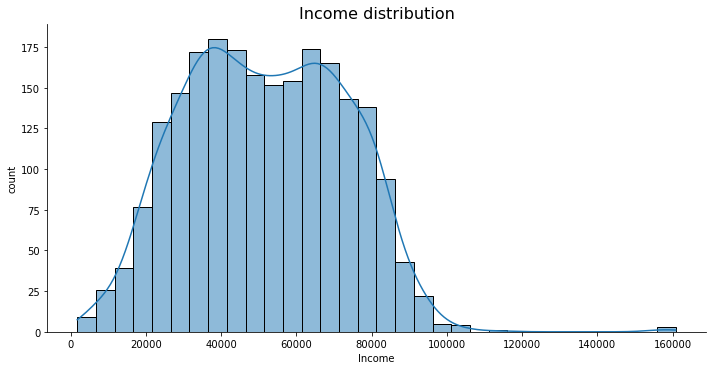

```python
#plotting displot for income

sns.displot(df['Income'], kde=True, height=5, aspect=2)
plt.title('Income distribution', size=16, )
plt.ylabel('count');
```

**Observations:**

- After treating outliers, the distribution for the income variable is close to normal distribution with very few extreme observations to the right.
- We will replace the missing values for the income variable with the median, and not mean, as the variable is slightly skewed to the right

```python
#filling null values with median

df['Income'].fillna(df.Income.median(), inplace=True)
```

### Analyzing all the campaigns

### **Question 2: Write your observations on acceptance rate for each campaign given in the below plot.** - 4 Marks

#### Let's find out what is the acceptance rate for each campaign?

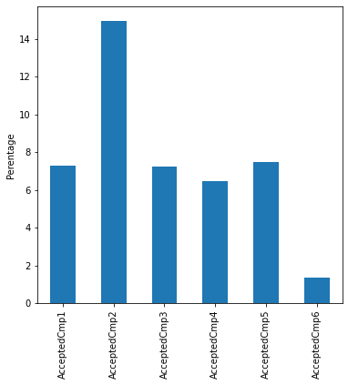

```python
# PLotting the % acceptance for every campaign

Camp_cols=['AcceptedCmp1', 'AcceptedCmp2', 'AcceptedCmp3', 'AcceptedCmp4', 'AcceptedCmp5', 'AcceptedCmp6']

success_campaign=(df[Camp_cols].sum()/df.shape[0])*100

# plot
success_campaign.plot(kind='bar', figsize=(6,6))
plt.ylabel("Perentage")
plt.show()
```

```python
success_campaign
```

```
AcceptedCmp1     7.302867
AcceptedCmp2    14.964158
AcceptedCmp3     7.258065
AcceptedCmp4     6.451613
AcceptedCmp5     7.482079
AcceptedCmp6     1.344086
dtype: float64
```

**Observations-**

- Please see coding above.
- Clearly Campaign 2 has the highest acceptance rate at ~15%. Campaign 1 (7.3%) ,3 (7.25%) ,4 (6.45%), and 5 (7.48%) are all between 6-8%. While the lone ranger, campaign 6, is sitting at a lowest of ~1.35%.

### Let's analyze what kind of customer are accepting campaigns?

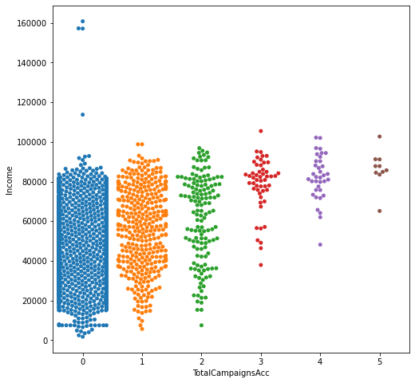

```python
plt.figure(figsize=(8,8))
sns.swarmplot(x='TotalCampaignsAcc', y='Income', data=df)
plt.show()
```

**Observations:**

- Higher the income higher the number of campaigns accepted.

```python
# Let's see the mean income of customers
df.Income.mean()
```

```
51762.59811827957
```

### **Question 3: Write your observations on acceptance rate for each campaign according to the income level.** - 7 Marks

The mean income of customers is close to 52K. Let's divide the income into 2 segments of income>52k and income<52k and see the acceptance rate in each segment.

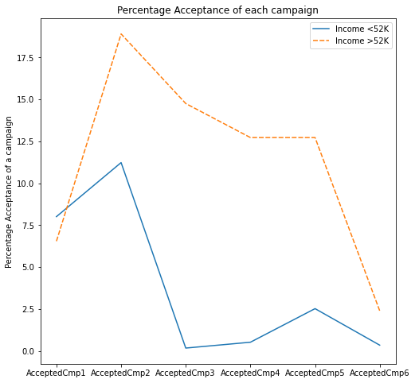

```python
# making dataframes of customers having income <52k and >52K
df1=df[df.Income<52000]
df2=df[df.Income>52000]

Camp_cols=['AcceptedCmp1', 'AcceptedCmp2', 'AcceptedCmp3', 'AcceptedCmp4', 'AcceptedCmp5', 'AcceptedCmp6']

#Calculating success rate of each campaign for both segments
success_campaign1=pd.DataFrame((df1[Camp_cols].sum()/df1.shape[0])*100, columns=['Income <52K'])

success_campaign2=pd.DataFrame((df2[Camp_cols].sum()/df2.shape[0])*100, columns=['Income >52K'])

new_df=pd.concat([success_campaign1, success_campaign2], axis=1)

# plot
plt.figure(figsize=(8,8))
sns.lineplot(data=new_df)
plt.title("Percentage Acceptance of each campaign")
plt.ylabel("Percentage Acceptance of a campaign")
plt.show()
```

```python
new_df
```

|  | Income <52K | Income >52K |
| --- | --- | --- |
| AcceptedCmp1 | 8.013937 | 6.549815 |
| AcceptedCmp2 | 11.236934 | 18.911439 |
| AcceptedCmp3 | 0.174216 | 14.760148 |
| AcceptedCmp4 | 0.522648 | 12.730627 |
| AcceptedCmp5 | 2.526132 | 12.730627 |
| AcceptedCmp6 | 0.348432 | 2.398524 |

**Observations:**

- Please see additional chart above for exact values and refernce
- a higher percentage of individuals who accepted Campaigns 2,3,4,5, and 6 had an income greater than 52k. More individuals with salary of less than 52k accepted campaign 1 (8% vs 6.5%).
- In campaign 1 both income segments start around the same area (~6.5-8%)
- As stated before campaign 2 has the highest acceptance rate for both categories of income.
- ~19% of individuals making more than 52k accepted CMP2 while ~11.2% making less than 52k accepted CMP2.
- Income <52k has lowest acceptance rate for Campaign 3, Income >52k has lowest acceptance rate for Campaign 6.
- Income <52k has a drastic drop from CMP2 to CMP3. Followed by a slight increase for CMP5. While Income >52k has a comparetively steady drop from CMP2 to CMP5, followed by a drastic drop to CMP6.

Let's find out who has accepted the last campaign and what could be the reason?

```python
df[df['AcceptedCmp6']==1].shape
```

```
(30, 31)
```

- There are only 30 customers who have accepted the last campaign.
- Let's check if these customers are new or they have accepted previous campaigns as well.

```python
grouped2=df.groupby('AcceptedCmp6').mean()['TotalCampaignsAcc']
grouped2
```

```
AcceptedCmp6
0    0.404632
1    3.633333
Name: TotalCampaignsAcc, dtype: float64
```

**Observations:**

- We know that the maximum number of campaigns any customer has accepted is 5.
- We can observe that the value for TotalCampaignsAcc is ~3.6 for customers who have accepted the last campaign.
- This implies that these 30 customers are those loyal customers who have been accepting most of the campaigns.

### It could be that different campaigns are focussed on different set of products. Let's check if the product preference for those who accepted the campaigns is different from those who didn't - using amount spent and number of purchases

Let's define a function which will take the column name for the product as input and will generate the line plot for every campaign and average amount spent on a product

```python
def amount_per_campaign(columns_name):
    p1=pd.DataFrame(df.groupby(['AcceptedCmp1']).mean()[columns_name]).T
    p2=pd.DataFrame(df.groupby(['AcceptedCmp2']).mean()[columns_name]).T
    p3=pd.DataFrame(df.groupby(['AcceptedCmp3']).mean()[columns_name]).T
    p4=pd.DataFrame(df.groupby(['AcceptedCmp4']).mean()[columns_name]).T
    p5=pd.DataFrame(df.groupby(['AcceptedCmp5']).mean()[columns_name]).T
    p6=pd.DataFrame(df.groupby(['AcceptedCmp6']).mean()[columns_name]).T
    pd.concat([p1,p2,p3,p4,p5,p6],axis=0).set_index([Camp_cols]).plot(kind='line', figsize=(8,8))
    plt.ylabel('Average amount spend on' + ' ' + columns_name)
    plt.show()
```

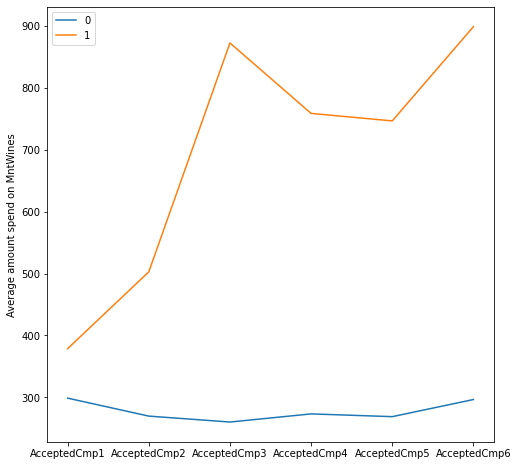

```python
#here is an example showing how to use this function on the column MntWines
amount_per_campaign('MntWines')
```

**Observations:**

- For the customers accepting campaign 3, 4, 5, and 6 the average amount spent on wine is quite high.